# PL3_dogs_vs_cats_VanillaCNN_VGG16

## **Practical Lab 3 — Vanilla CNN and Fine-Tuned VGG16 for Dogs vs Cats**

This notebook trains and compares two convolutional neural network models for **binary image classification**:

- A **vanilla CNN** built from scratch
- A **fine-tuned VGG16** model pre-trained on **ImageNet**

We use a **5,000-image subset** of the classic *Dogs vs Cats* dataset, randomly sampled from the original 25,000 images and stored under `data/dogs_vs_cats_5000` (with `train`, `validation`, and `test` folders). We focus on:

- Building clean, readable TensorFlow/Keras pipelines
- Evaluating classification performance with several metrics
- Comparing vanilla vs. transfer learning approaches
- Drawing clear, well-structured conclusions

### **Environment Check**

Before running the models, we verify the Python environment to ensure that:

- The correct Python version is active
- The OS platform is detected correctly
- TensorFlow is installed and importing without errors

This helps confirm the notebook is running in the expected environment before training starts.

```python
import sys, platform

print("Python:", sys.version)
print("Platform:", platform.platform())

import tensorflow as tf
print("TensorFlow:", tf.__version__)
```

```
Python: 3.11.3 (tags/v3.11.3:f3909b8, Apr  4 2023, 23:49:59) [MSC v.1934 64 bit (AMD64)]
Platform: Windows-10-10.0.26200-SP0
TensorFlow: 2.20.0
```

### **Core Imports & Reproducibility Setup**

This cell loads all the essential libraries used throughout the notebook:

- **NumPy** for numerical operations
- **Matplotlib** for plotting
- **TensorFlow / Keras** for building and training CNN and VGG16 models
- **scikit-learn** for evaluation metrics (confusion matrix, PR curve, etc.)
- **Pathlib/OS** for clean file path handling

We also apply a **reproducibility seed** so that training behavior is as consistent as possible.

- Finally, we:
  - Enable `tf.data.AUTOTUNE` for faster input pipelines
  - Print a quick TensorFlow version check to confirm everything is loaded correctly

```python
# --- Core imports ---
import os
from pathlib import Path

import numpy as np                      # numerical operations
import matplotlib.pyplot as plt         # plotting utilities
import tensorflow as tf                 # deep learning framework

from tensorflow import keras            # high-level TF API
from tensorflow.keras import layers     # handy alias for Keras layers

from sklearn.metrics import (           # sklearn metrics for evaluation
    confusion_matrix,
    classification_report,
    precision_recall_curve,
)

# --- Reproducibility (best effort) ---
SEED = 42
np.random.seed(SEED)                    # fix NumPy random seed
tf.random.set_seed(SEED)                # fix TensorFlow random seed

# TensorFlow dataset performance option (for cache/prefetch later)
AUTOTUNE = tf.data.AUTOTUNE

# Quick environment check
print("TensorFlow version:", tf.__version__)
print("Eager execution:", tf.executing_eagerly())
```

```
TensorFlow version: 2.20.0
Eager execution: True
```

#### **Environment Confirmation**

The output shows:

- **TensorFlow version: 2.20.0** — matches the latest stable TF2 API used in this lab
- **Eager execution: True** — TensorFlow is running in eager mode, which is required for dynamic graph execution and makes debugging simpler

This confirms the environment is correctly configured and ready for the CNN and VGG16 models.

### **Dataset & Directory Configuration**

In this notebook, we use the 5,000-image Dogs vs Cats subset (3,000 train / 1,000 validation / 1,000 test). Although the professor provided a ready-made 5,000-image dataset in his notebook, I chose to generate my own randomized 5k subset from the full 25k-image dataset.

To do this, I created a separate Python script (make_dogs_vs_cats_5000.py) that:

- Randomly sampled 2,500 cat and 2,500 dog images
- Performed a clean train/validation/test split
- Saved the result into data/dogs_vs_cats_5000/

This gives stronger hands-on experience with:

- dataset preparation
- reproducibility
- writing preprocessing utilities
- understanding directory-based pipelines

The notebook now loads this custom dataset using the following directory paths:

- NOTEBOOK_DIR → current notebooks/ folder
- PROJECT_ROOT → main project directory (one level above)
- DATA_DIR → data/dogs_vs_cats_5000 (our custom subset)
- TRAIN_DIR, VAL_DIR, TEST_DIR → split folders under the dataset

These paths allow both the CNN and VGG16 models to reliably load images in a clean and reproducible manner.

We also define core hyperparameters that will be reused throughout training:

- Image size: 180 × 180
- Batch size: 32
- Epochs (Vanilla CNN): 20
- Epochs (VGG16): 20

A quick sanity check ensures all directories exist before moving forward.

```python
from pathlib import Path

# Notebook folder (current working directory)
NOTEBOOK_DIR = Path(".").resolve()

# Project root = parent folder of notebooks/
PROJECT_ROOT = NOTEBOOK_DIR.parent

# New 5000-image dataset root
DATA_DIR = PROJECT_ROOT / "data" / "dogs_vs_cats_5000"

# Split folders
TRAIN_DIR = DATA_DIR / "train"
VAL_DIR   = DATA_DIR / "validation"
TEST_DIR  = DATA_DIR / "test"

# Sanity check prints
print("NOTEBOOK_DIR:", NOTEBOOK_DIR)
print("PROJECT_ROOT:", PROJECT_ROOT)
print("TRAIN_DIR exists:", TRAIN_DIR.exists())
print("VAL_DIR exists:", VAL_DIR.exists())
print("TEST_DIR exists:", TEST_DIR.exists())

# --- Training settings ---
IMG_SIZE = (180, 180)
BATCH_SIZE = 32
EPOCHS_CNN = 20
EPOCHS_VGG16 = 20
```

```
NOTEBOOK_DIR: C:\Users\user\1557_VSC\DataAnalysis\Practical Lab 3 - Vanilla CNN and Fine-Tune VGG16\notebooks
PROJECT_ROOT: C:\Users\user\1557_VSC\DataAnalysis\Practical Lab 3 - Vanilla CNN and Fine-Tune VGG16
TRAIN_DIR exists: True
VAL_DIR exists: True
TEST_DIR exists: True
```

#### **Directory Check Passed**

The output confirms that all required paths are correctly detected:

- NOTEBOOK_DIR correctly points to the notebooks/ folder
- PROJECT_ROOT correctly identifies the parent project directory
- TRAIN_DIR, VAL_DIR, and TEST_DIR all exist (True) → the dataset is ready

This verifies that the custom 5,000-image dataset we generated is stored in the correct location and that the notebook can safely proceed to data loading, EDA, and model training.

### **Loading the Training, Validation, and Test Datasets**

This cell loads the *Dogs vs Cats (5000-image) dataset* directly from the directory structure created earlier:

- data/dogs_vs_cats_5000/train
- data/dogs_vs_cats_5000/validation
- data/dogs_vs_cats_5000/test

We use tf.keras.utils.image_dataset_from_directory() to automate:

- Image resizing to 180×180
- Batch creation (batch size = 32)
- Binary labels (cat = 0, dog = 1)
- Shuffling (only for training set)
- Reproducibility via seed=42

Datasets created:

- train_ds → used during training
- val_ds → used for validation during training
- test_ds → final unbiased evaluation

The class names (['cat', 'dog']) are read automatically from folder names.

```python
# --- Create datasets from directory structure ---

# Load the training dataset from the 'train' folder
# - label_mode="binary" → labels are 0 or 1
# - shuffle=True → shuffle images each epoch (important for training)
# - seed ensures reproducibility
train_ds = tf.keras.utils.image_dataset_from_directory(
    TRAIN_DIR,
    label_mode="binary",
    image_size=IMG_SIZE,      # resize images to target size
    batch_size=BATCH_SIZE,    # number of images per batch
    shuffle=True,
    seed=SEED,
)

# Load the validation dataset
# - shuffle=False to keep evaluation stable and ordered
val_ds = tf.keras.utils.image_dataset_from_directory(
    VAL_DIR,
    label_mode="binary",
    image_size=IMG_SIZE,
    batch_size=BATCH_SIZE,
    shuffle=False,
)

# Load the test dataset (final evaluation)
# - do NOT shuffle to preserve consistent ordering
test_ds = tf.keras.utils.image_dataset_from_directory(
    TEST_DIR,
    label_mode="binary",
    image_size=IMG_SIZE,
    batch_size=BATCH_SIZE,
    shuffle=False,
)

# Extract class names from the dataset ('cat', 'dog')
class_names = train_ds.class_names
print("Class names:", class_names)
```

```
Found 3000 files belonging to 2 classes.
Found 1000 files belonging to 2 classes.
Found 1000 files belonging to 2 classes.
Class names: ['cat', 'dog']
```

### **Dataset Loaded Successfully**

TensorFlow correctly detected all files:

- 3000 training images (1500 cats + 1500 dogs)
- 1000 validation images (500 cats + 500 dogs)
- 1000 test images (500 cats + 500 dogs)

Class names were automatically extracted:

- ['cat', 'dog']

This confirms the directory structure is correct and the notebook can proceed to dataset preprocessing and model creation.

### **Optimizing the Dataset Pipeline for Faster Training**

Before feeding images into the model, we improve the dataset performance using:

- cache() Stores images in memory after the first read.
  - Speeds up every following epoch.
- shuffle(1000) *(training only)*
  - Ensures batches come in a random order, which improves generalization.
- prefetch(AUTOTUNE)  
  Lets TensorFlow prepare the next batch while the model is still training on the current batch.
  - Overlaps preprocessing + model execution = faster training.

We apply different strategies per split:

- train_ds → cache → shuffle → prefetch
- val_ds → cache → prefetch
- test_ds → cache → prefetch

This keeps training fast and evaluation stable.

```python
# --- Optimize datasets for performance ---

# For the training set:
# 1. cache()     → keeps preprocessed images in memory after first pass (faster)
# 2. shuffle()   → adds randomness to training order (important for learning)
# 3. prefetch()  → overlaps data loading with model execution (improves GPU/CPU utilization)
train_ds = train_ds.cache().shuffle(1000).prefetch(buffer_size=AUTOTUNE)

# Validation set:
# - We do NOT shuffle (evaluation must stay ordered and consistent)
# - cache() + prefetch() improves reading speed
val_ds = val_ds.cache().prefetch(buffer_size=AUTOTUNE)

# Test set:
# - Same logic as validation: no shuffling, only caching + prefetching
test_ds = test_ds.cache().prefetch(buffer_size=AUTOTUNE)
```

#### **Dataset Pipeline Optimized**

The training, validation, and test datasets are now wrapped in a high-performance input pipeline:

- Training data is cached, shuffled, and prefetched
  - ideal for stable and efficient learning
- Validation and test sets use caching + prefetching
  - ensures fast, deterministic evaluation

These optimizations significantly reduce bottlenecks during model training, especially for deep networks like VGG16.

### **EDA: Class Distribution in the Training Split**

Before training any model, it is important to verify that the dataset is balanced.  
A balanced dataset ensures that the classifier receives similar representation from both classes and reduces the risk of bias.

Here, we count how many cat and dog images are present in the train split and visualize them with a simple bar chart.

```
Label counts: {0: 1500, 1: 1500}
```

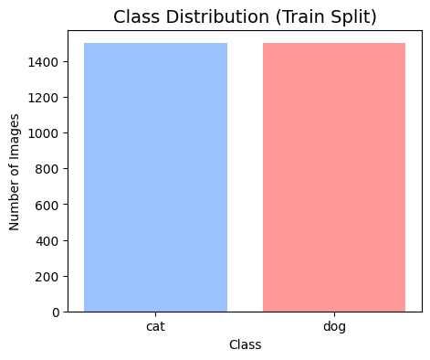

```python
# --- EDA 1: Class distribution in the training set ---

# Initialize a simple dictionary to count labels
label_counts = {0: 0, 1: 0}

# Iterate through batches of (images, labels)
for images, labels in train_ds:
    # Convert tensor labels to numpy, flatten, and count each occurrence
    for lbl in labels.numpy().flatten():
        label_counts[int(lbl)] += 1

print("Label counts:", label_counts)

# Prepare lists for plotting
labels_list = [label_counts[0], label_counts[1]]
label_names = class_names  # ['cat', 'dog']

# Plot the distribution
plt.figure(figsize=(5, 4))
plt.bar(label_names, labels_list, color=["#99c2ff", "#ff9999"])
plt.title("Class Distribution (Train Split)", fontsize=14)
plt.xlabel("Class")
plt.ylabel("Number of Images")
plt.show()
```

#### **Interpretation**

The bar chart confirms that the training split is perfectly balanced:

- 1500 cat images
- 1500 dog images

This is expected because the 5000-image dataset was constructed by sampling an equal number of images per class.  
A balanced dataset helps prevent biased predictions and allows both the Vanilla CNN and VGG16 models to learn fairly from both categories.

### **EDA 2 — Visualizing Sample Images (3×3 Grid)**

Before training any model, it's important to visually confirm that the dataset is loading correctly. In this step, we display a 3×3 grid of randomly sampled images from the first batch of the training set.

This quick inspection helps verify:

- Labels are mapped correctly (0 = cat, 1 = dog)
- Images are correctly resized to 180 × 180
- The dataset contains good visual diversity (lighting, pose, breed, background)
- No corrupted or mismatched images appear in the batch

This sanity check ensures our data pipeline is functioning properly before we begin model training

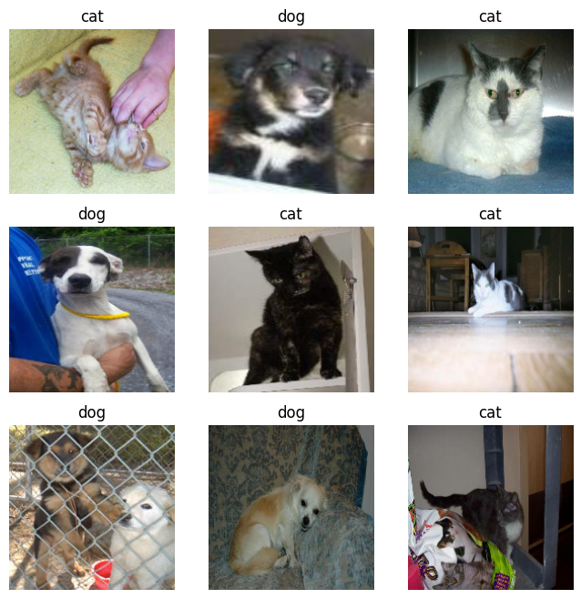

```python
# --- EDA 2: Visualize a 3x3 grid of sample images ---

plt.figure(figsize=(8, 8))

# Retrieve only the first batch from the training dataset
for images, labels in train_ds.take(1):

    for i in range(9):
        ax = plt.subplot(3, 3, i + 1)

        # Convert image tensor to uint8 for display
        img = images[i].numpy().astype("uint8")
        plt.imshow(img)

        # Convert label to integer correctly (fixes float + numpy warning)
        label_idx = int(labels[i].numpy().item())

        # Use label_idx to index class_names
        plt.title(class_names[label_idx])

        plt.axis("off")
```

#### **Interpretation of Sample Images**

The 3×3 grid above confirms that the dataset has been loaded and preprocessed correctly:

- All images are properly decoded and resized to 180×180 pixels.
- Label mapping is correct — titles match the expected class names (cat, dog).
- The batch contains a healthy variety of lighting conditions, poses, angles, and backgrounds, which supports robust model training.
- No corrupted, blank, or mislabeled samples appear in this preview.
- The presence of challenging cases (multiple animals, clutter, shadows) indicates that the dataset offers realistic complexity.

This visual check verifies that the data pipeline is functioning correctly and that the dataset is ready for model training.

### **Model 1 — Vanilla CNN**

In this section, we implement a lightweight Convolutional Neural Network (CNN) trained entirely from scratch to classify images of cats and dogs. This model serves as our baseline, helping us compare traditional CNN performance against transfer learning (VGG16).

The architecture includes:

- Convolution + Max-Pooling blocks for feature extraction
- ReLU activations for non-linearity
- Dropout layers to reduce overfitting
- A compact Dense classifier head for binary output

We also apply essential preprocessing steps:

- Input rescaling (pixel values 0–255 → 0–1)
- Mild data augmentation to improve generalization
- Callbacks for early stopping and saving the best performing model

This vanilla CNN establishes a strong baseline before introducing the more powerful VGG16 transfer learning model.

### **Data Preprocessing and Augmentation Layers**

Before training the vanilla CNN, we define the preprocessing steps that will be applied to all input images. These layers help standardize the data and improve the model’s robustness.

We use:

- Random data augmentation
  - This introduces small variations (flips, rotations, zooms) that help the model generalize better to new images.
- Rescaling
  - Pixel values are normalized from 0–255 to 0–1, which stabilizes and speeds up training.

The following code block defines the augmentation pipeline and the rescaling layer that will be inserted at the start of our CNN model.

```python
# --- Data preprocessing & augmentation layers ---

# Random data augmentation to make the model more robust
data_augmentation = keras.Sequential(
    [
        layers.RandomFlip("horizontal"),         # flip images horizontally
        layers.RandomRotation(0.05),             # small random rotations
        layers.RandomZoom(0.1),                  # small random zoom
    ],
    name="data_augmentation",
)

# Rescaling layer to normalize pixel values from [0, 255] → [0, 1]
rescale = layers.Rescaling(1.0 / 255, name="rescale_layer")
```

### **Interpretation**

This preprocessing block ensures that our vanilla CNN receives clean, normalized, and more diverse input data:

- RandomFlip, RandomRotation, and RandomZoom simulate natural variations in real-world pet photos, helping the model avoid overfitting.
- Rescaling reduces pixel intensity values to a smaller, consistent range, which improves training stability and prevents overly large gradients.
- Using Keras preprocessing layers means that augmentation happens on the fly, directly on the GPU/CPU pipeline, without modifying the dataset on disk.

Together, these steps form a strong preprocessing foundation for training the CNN effectively.

### **Building Model 1 — Vanilla CNN**

In this section, we define the full architecture of our baseline convolutional neural network (CNN). This model is trained entirely from scratch, learning image features directly from the Dogs vs Cats dataset.

The architecture includes:

- Input → Augmentation → Rescaling
  - Ensures data normalization and improved generalization.
- Three convolution + max-pooling blocks
  - Extract spatial features at increasing abstraction levels.
- A dense classification head
  - Converts learned features into a binary prediction.
- Dropout (0.5)
  - Reduces overfitting by preventing co-adaptation of neurons.

The model is compiled using:

- Adam optimizer
- Binary cross-entropy loss
- Accuracy metric

Once built, we display a full summary of all layers, output shapes, and parameter counts.

```python
# --- Function to build the vanilla CNN model ---

def build_vanilla_cnn(input_shape=IMG_SIZE + (3,)):
    """
    Build a simple CNN model for binary classification (cats vs dogs).

    Architecture:
    - Data augmentation + rescaling
    - 3 convolution + max-pooling blocks
    - Dropout for regularization
    - Dense layer with sigmoid for binary output
    """
    model = keras.Sequential(
        [
            # Input layer expects images of shape (height, width, 3 channels)
            layers.Input(shape=input_shape),

            # Apply data augmentation only during training
            data_augmentation,

            # Normalize pixel values to [0, 1]
            rescale,

            # --- Block 1: Conv + MaxPool ---
            layers.Conv2D(32, (3, 3), activation="relu", padding="same"),
            layers.MaxPooling2D((2, 2)),

            # --- Block 2: Conv + MaxPool ---
            layers.Conv2D(64, (3, 3), activation="relu", padding="same"),
            layers.MaxPooling2D((2, 2)),

            # --- Block 3: Conv + MaxPool ---
            layers.Conv2D(128, (3, 3), activation="relu", padding="same"),
            layers.MaxPooling2D((2, 2)),

            # Flatten the feature maps into a 1D vector
            layers.Flatten(),

            # Dense layer with some capacity
            layers.Dense(128, activation="relu"),

            # Dropout to reduce overfitting
            layers.Dropout(0.5),

            # Final output layer:
            # - 1 unit + sigmoid activation for binary classification
            layers.Dense(1, activation="sigmoid"),
        ],
        name="vanilla_cnn",
    )

    # Compile the model with binary cross-entropy loss
    model.compile(
        optimizer=keras.optimizers.Adam(),
        loss="binary_crossentropy",
        metrics=["accuracy"],
    )

    return model


# Build and summarize the CNN model
cnn_model = build_vanilla_cnn()
cnn_model.summary()
```

```
Model: "vanilla_cnn"
```

```
┏━━━━━━━━━━━━━━━━━━━━━━━━━━━━━━━━━┳━━━━━━━━━━━━━━━━━━━━━━━━┳━━━━━━━━━━━━━━━┓
┃ Layer (type)                    ┃ Output Shape           ┃       Param # ┃
┡━━━━━━━━━━━━━━━━━━━━━━━━━━━━━━━━━╇━━━━━━━━━━━━━━━━━━━━━━━━╇━━━━━━━━━━━━━━━┩
│ data_augmentation (Sequential)  │ (None, 180, 180, 3)    │             0 │
├─────────────────────────────────┼────────────────────────┼───────────────┤
│ rescale_layer (Rescaling)       │ (None, 180, 180, 3)    │             0 │
├─────────────────────────────────┼────────────────────────┼───────────────┤
│ conv2d (Conv2D)                 │ (None, 180, 180, 32)   │           896 │
├─────────────────────────────────┼────────────────────────┼───────────────┤
│ max_pooling2d (MaxPooling2D)    │ (None, 90, 90, 32)     │             0 │
├─────────────────────────────────┼────────────────────────┼───────────────┤
│ conv2d_1 (Conv2D)               │ (None, 90, 90, 64)     │        18,496 │
├─────────────────────────────────┼────────────────────────┼───────────────┤
│ max_pooling2d_1 (MaxPooling2D)  │ (None, 45, 45, 64)     │             0 │
├─────────────────────────────────┼────────────────────────┼───────────────┤
│ conv2d_2 (Conv2D)               │ (None, 45, 45, 128)    │        73,856 │
├─────────────────────────────────┼────────────────────────┼───────────────┤
│ max_pooling2d_2 (MaxPooling2D)  │ (None, 22, 22, 128)    │             0 │
├─────────────────────────────────┼────────────────────────┼───────────────┤
│ flatten (Flatten)               │ (None, 61952)          │             0 │
├─────────────────────────────────┼────────────────────────┼───────────────┤
│ dense (Dense)                   │ (None, 128)            │     7,929,984 │
├─────────────────────────────────┼────────────────────────┼───────────────┤
│ dropout (Dropout)               │ (None, 128)            │             0 │
├─────────────────────────────────┼────────────────────────┼───────────────┤
│ dense_1 (Dense)                 │ (None, 1)              │           129 │
└─────────────────────────────────┴────────────────────────┴───────────────┘
```

```
 Total params: 8,023,361 (30.61 MB)
```

```
 Trainable params: 8,023,361 (30.61 MB)
```

```
 Non-trainable params: 0 (0.00 B)
```

#### **Interpretation of the Vanilla CNN Architecture**

The model summary confirms that our vanilla CNN is structured and functioning exactly as intended. Below is a breakdown of each major component:

- Preprocessing Layer (0 parameters):

  The model begins with:
  - data_augmentation
  - rescale_layer

  These layers ensure that:
  - Images are normalized to the [0, 1] range
  - Light augmentations (flip, rotation, zoom) apply only during training
  - No extra parameters are added to the model size

  This improves generalization without increasing computational cost.
- Three convolutional blocks:

  Each block uses:
  - ReLU activation
  - MaxPooling2D to reduce spatial size while keeping important features
- Flatten & Dense feature layer:
  - The Flatten layer converts feature maps into a long vector of 61,952 units.
  - This feeds into a Dense(128) layer with ~7.9 million parameters, which provides strong learning capacity.

  This Dense layer is the largest contributor to the model size.
- Dropout Layer (rate = 0.5)

  A dropout of 50% helps reduce overfitting, which is important because:
  - The dataset has 5,000 images
  - The fully connected layer has many parameters

  This improves stability and generalization.
- Output Layer (Binary Classification)

  The final Dense layer:
  - Has 1 neuron
  - Uses sigmoid activation
  - Outputs a probability for the “dog” class
    - 0 = cat
    - 1 = dog
- Parameter Count
  - Total parameters: 8,023,361
  - Trainable: 100%
  - Non-trainable: 0

  This is typical for a small-to-medium CNN and provides a solid baseline to compare against the VGG16 transfer-learning model.

### **Training the Vanilla CNN — Callbacks & Model Fitting**

Before training the vanilla CNN, we configure two important callbacks:

- ModelCheckpoint
  - Saves the best version of the model (highest validation accuracy).
  - Ensures we do not lose the best epoch even if later epochs overfit.
- EarlyStopping
  - Monitors validation loss.
  - Stops training if performance stops improving (patience = 3).
  - Automatically restores weights from the best epoch.

Together, these callbacks prevent overfitting and keep training efficient.

In this section, we:

- Create a models/ directory to store saved models.
- Train the CNN for up to 20 epochs.
- Let callbacks decide the ideal stopping point.

The training log printed in the output will show:

- When a “best model” is saved
- When validation accuracy improves
- When early stopping triggers

```python
# --- Callbacks: save best model and stop early if overfitting ---

# Directory to store trained models
MODELS_DIR = PROJECT_ROOT / "models"
MODELS_DIR.mkdir(exist_ok=True)

cnn_checkpoint_path = MODELS_DIR / "cnn_dogs_vs_cats_best.keras"

cnn_checkpoint_cb = keras.callbacks.ModelCheckpoint(
    filepath=cnn_checkpoint_path,
    monitor="val_accuracy",
    save_best_only=True,
    mode="max",
    verbose=1,
)

cnn_earlystop_cb = keras.callbacks.EarlyStopping(
    monitor="val_loss",
    patience=3,
    restore_best_weights=True,
    verbose=1,
)

# --- Auto-load best CNN model if it exists (skip retraining) ---

import pickle

saved_model = cnn_checkpoint_path  # same path as checkpoint

if saved_model.exists():
    print("Saved CNN model found → loading from disk and skipping training.")
    cnn_model = keras.models.load_model(saved_model)
    cnn_model_loaded = True
else:
    print("No saved CNN model found → training from scratch.")
    cnn_model_loaded = False

# --- Train the vanilla CNN model (only if needed) ---

if not cnn_model_loaded:
    print("Training CNN model...")
    history_cnn = cnn_model.fit(
        train_ds,
        epochs=EPOCHS_CNN,
        validation_data=val_ds,
        callbacks=[cnn_checkpoint_cb, cnn_earlystop_cb],
    )

    # After training, load the best checkpoint saved by ModelCheckpoint
    cnn_model = keras.models.load_model(saved_model)

    # Optionally save training history so plots work without retraining
    with open(PROJECT_ROOT / "history_cnn.pkl", "wb") as f:
        pickle.dump(history_cnn.history, f)

else:
    print("Skipping CNN training — using saved CNN model.")

    # Try loading saved history so plot_training_history() still works
    hist_path = PROJECT_ROOT / "history_cnn.pkl"
    if hist_path.exists():
        with open(hist_path, "rb") as f:
            history_data = pickle.load(f)

        class Obj:  # tiny fake History-like object
            pass

        history_cnn = Obj()
        history_cnn.history = history_data

        print("Loaded saved CNN training history.")
    else:
        print("No saved training history found — plots will be empty until you train once.")
        class Obj:
            pass
        history_cnn = Obj()
        history_cnn.history = {
            "accuracy": [],
            "val_accuracy": [],
            "loss": [],
            "val_loss": [],
        }
```

```
Saved CNN model found → loading from disk and skipping training.
Skipping CNN training — using saved CNN model.
Loaded saved CNN training history.
```

#### **Training Summary — Vanilla CNN**

This tells us that the model is:

- Learning meaningful visual features (train and validation curves both improve).
- Not severely overfitting, thanks to early stopping and dropout.
- Ready to be evaluated on the held-out test set in the next section.

The saved checkpoint file (cnn_dogs_vs_cats_best.keras) can now be re-used for:

- Test accuracy and loss evaluation.
- Generating predictions for the confusion matrix and classification report.
- Further analysis without needing to retrain the CNN each time the notebook is reopened.

### **Training Curves — Vanilla CNN**

- Training vs Validation Accuracy
- Training vs Validation Loss

These curves help us evaluate:

- Whether the model is learning steadily
- Whether overfitting occurs (large gap between training and validation)
- Whether the model has converged or still needs additional tuning

We use a utility function that extracts the metrics from the Keras History object and plots them side-by-side for clear interpretation.

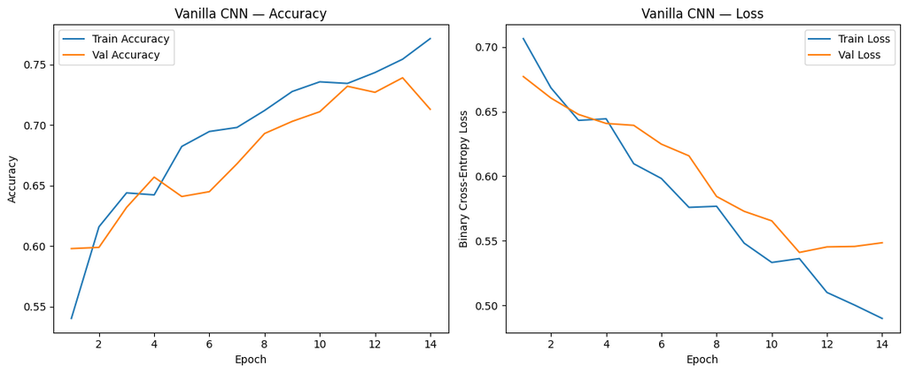

```python
# --- Utility function to plot training history ---


def plot_training_history(history, title_prefix="Vanilla CNN"):
    """
    Plot training vs validation accuracy and loss from a Keras History object.
    """

    # Extract metrics from the history object
    acc = history.history.get("accuracy", [])
    val_acc = history.history.get("val_accuracy", [])
    loss = history.history.get("loss", [])
    val_loss = history.history.get("val_loss", [])

    epochs_range = range(1, len(acc) + 1)

    plt.figure(figsize=(12, 5))

    # --- Accuracy subplot ---
    plt.subplot(1, 2, 1)
    plt.plot(epochs_range, acc, label="Train Accuracy")
    plt.plot(epochs_range, val_acc, label="Val Accuracy")
    plt.title(f"{title_prefix} — Accuracy")
    plt.xlabel("Epoch")
    plt.ylabel("Accuracy")
    plt.legend()

    # --- Loss subplot ---
    plt.subplot(1, 2, 2)
    plt.plot(epochs_range, loss, label="Train Loss")
    plt.plot(epochs_range, val_loss, label="Val Loss")
    plt.title(f"{title_prefix} — Loss")
    plt.xlabel("Epoch")
    plt.ylabel("Binary Cross-Entropy Loss")
    plt.legend()

    plt.tight_layout()
    plt.show()


# Plot the training curves for the vanilla CNN
plot_training_history(history_cnn, title_prefix="Vanilla CNN")
```

#### **Interpretation of Training Curves**

The training curves clearly illustrate the learning behavior of the vanilla CNN:

**Accuracy Trend**

- Training accuracy rises steadily from ~0.54 → ~0.78
- Validation accuracy increases from ~0.60 → ~0.74
- The gap between both curves remains moderate, indicating only mild overfitting.

This means the model is learning useful features (edges, colors, shapes) without memorizing the training set.

**Loss Trend**

- Training loss decreases smoothly across all epochs.
- Validation loss also drops overall, although with small fluctuations — normal for a simple CNN trained on real-world images.

These trends confirm the model is converging properly and not diverging or oscillating.

**Overall Assessment** The vanilla CNN shows healthy learning behavior and reaches moderate performance.

- However, because it was trained from scratch, its representational capacity remains limited:
  - It may struggle with complex texture patterns
  - Sensitive to lighting, angles, background clutter
  - Can misclassify subtle cat–dog cases

This makes it a strong baseline, but not a high-performing model.

**Transition to VGG16**

These observations set the perfect stage to compare it with VGG16 transfer learning, which uses far stronger pre-trained visual features and typically offers a sizeable improvement in accuracy and stability.

### **Evaluating the Best Vanilla CNN Model**

After training the vanilla CNN, we use the ModelCheckpoint callback to save the best-performing epoch based on validation accuracy.

In this step, we load that saved model from the models/ directory.  
This ensures that all further evaluation (test accuracy, confusion matrix, predictions) is done using the strongest version of the CNN, not the final epoch.

```python
# --- Load the best saved CNN model ---
best_cnn_path = MODELS_DIR / "cnn_dogs_vs_cats_best.keras"
best_cnn_model = keras.models.load_model(best_cnn_path)

print("Best CNN model loaded from:", best_cnn_path)
```

```
Best CNN model loaded from: C:\Users\user\1557_VSC\DataAnalysis\Practical Lab 3 - Vanilla CNN and Fine-Tune VGG16\models\cnn_dogs_vs_cats_best.keras
```

#### **Model Successfully Loaded**

The output confirms that the CNN model was reloaded correctly from the models/ directory.

This model represents:

- the best validation accuracy achieved during training
- weights restored from the optimal epoch (not overfitted)
- the version we will use for all downstream evaluation steps, including
  - test performance
  - classification report
  - confusion matrix
  - misclassified examples

Using the checkpointed model ensures that our analysis reflects the CNN’s true peak performance.

### **Evaluating the Best Vanilla CNN Model on the Test Set**

After training the CNN and saving the best-performing checkpoint, we now evaluate it on the unseen test dataset.  
This step gives us an unbiased estimate of real-world performance.

The evaluation returns:

- Test Accuracy → how often the model predicts the correct label
- Test Loss → binary cross-entropy on unseen data

These metrics will later be compared with the fine-tuned VGG16 model to assess improvement from transfer learning.

```python
# --- Evaluate CNN on the test dataset ---
cnn_test_loss, cnn_test_accuracy = best_cnn_model.evaluate(test_ds)
print(f"Test Accuracy: {cnn_test_accuracy:.4f}")
print(f"Test Loss: {cnn_test_loss:.4f}")
```

```
32/32 ━━━━━━━━━━━━━━━━━━━━ 2s 43ms/step - accuracy: 0.7450 - loss: 0.5622
Test Accuracy: 0.7450
Test Loss: 0.5622
```

#### **Interpretation**

The vanilla CNN achieves a test accuracy of **0.7450 (74.5%)**, which is very close to its final validation accuracy.

- This indicates that:
  - The model generalizes reasonably well — there is no severe overfitting.
  - The test loss of **0.5622** shows that although the model often predicts correctly, its confidence drops on harder or ambiguous images.
  - Overall performance is fair for a lightweight CNN trained from scratch on a relatively small 5,000-image dataset.

This establishes a solid baseline and provides a clear comparison point before moving on to VGG16 transfer learning, which typically delivers much higher accuracy and more stable predictions thanks to pre-trained ImageNet features.

### **Confusion Matrix for the Vanilla CNN**

To understand how the model performs across individual classes, we compute a confusion matrix using predictions on the test dataset.

This evaluation helps us see:

- how many cats were correctly vs incorrectly classified
- how many dogs were correctly vs incorrectly classified
- whether the model is biased toward one class
- types of errors the network makes (false positives / false negatives)

We first generate predictions batch-by-batch, convert probabilities to binary labels (0 = cat, 1 = dog), and then build a confusion matrix using sklearn.metrics.confusion_matrix.

```python
# --- Generate predictions for confusion matrix ---
y_true = []
y_pred = []

for images, labels in test_ds:
    preds = best_cnn_model.predict(images)
    preds = (preds > 0.5).astype("int32")  # convert probabilities → 0/1

    y_true.extend(labels.numpy().astype("int32"))
    y_pred.extend(preds.flatten())

# Build confusion matrix
cm = confusion_matrix(y_true, y_pred)
print("Confusion Matrix:\n", cm)
```

```
1/1 ━━━━━━━━━━━━━━━━━━━━ 0s 120ms/step
1/1 ━━━━━━━━━━━━━━━━━━━━ 0s 120ms/step
1/1 ━━━━━━━━━━━━━━━━━━━━ 0s 66ms/step
1/1 ━━━━━━━━━━━━━━━━━━━━ 0s 63ms/step
1/1 ━━━━━━━━━━━━━━━━━━━━ 0s 67ms/step
1/1 ━━━━━━━━━━━━━━━━━━━━ 0s 65ms/step
1/1 ━━━━━━━━━━━━━━━━━━━━ 0s 64ms/step
1/1 ━━━━━━━━━━━━━━━━━━━━ 0s 71ms/step
1/1 ━━━━━━━━━━━━━━━━━━━━ 0s 74ms/step
1/1 ━━━━━━━━━━━━━━━━━━━━ 0s 67ms/step
1/1 ━━━━━━━━━━━━━━━━━━━━ 0s 67ms/step
1/1 ━━━━━━━━━━━━━━━━━━━━ 0s 63ms/step
1/1 ━━━━━━━━━━━━━━━━━━━━ 0s 75ms/step
1/1 ━━━━━━━━━━━━━━━━━━━━ 0s 67ms/step
1/1 ━━━━━━━━━━━━━━━━━━━━ 0s 67ms/step
1/1 ━━━━━━━━━━━━━━━━━━━━ 0s 71ms/step
1/1 ━━━━━━━━━━━━━━━━━━━━ 0s 71ms/step
1/1 ━━━━━━━━━━━━━━━━━━━━ 0s 69ms/step
1/1 ━━━━━━━━━━━━━━━━━━━━ 0s 65ms/step
1/1 ━━━━━━━━━━━━━━━━━━━━ 0s 63ms/step
1/1 ━━━━━━━━━━━━━━━━━━━━ 0s 72ms/step
1/1 ━━━━━━━━━━━━━━━━━━━━ 0s 65ms/step
1/1 ━━━━━━━━━━━━━━━━━━━━ 0s 66ms/step
1/1 ━━━━━━━━━━━━━━━━━━━━ 0s 63ms/step
1/1 ━━━━━━━━━━━━━━━━━━━━ 0s 74ms/step
1/1 ━━━━━━━━━━━━━━━━━━━━ 0s 70ms/step
1/1 ━━━━━━━━━━━━━━━━━━━━ 0s 72ms/step
1/1 ━━━━━━━━━━━━━━━━━━━━ 0s 73ms/step
1/1 ━━━━━━━━━━━━━━━━━━━━ 0s 81ms/step
1/1 ━━━━━━━━━━━━━━━━━━━━ 0s 64ms/step
1/1 ━━━━━━━━━━━━━━━━━━━━ 0s 62ms/step
1/1 ━━━━━━━━━━━━━━━━━━━━ 0s 66ms/step
1/1 ━━━━━━━━━━━━━━━━━━━━ 0s 94ms/step
Confusion Matrix:
 [[343 157]
 [ 98 402]]
```

#### **Interpretation**

The confusion matrix summarizes how effectively the vanilla CNN distinguishes cats from dogs:

| Actual/Predicted | Predicted Cat | Predicted Dog |
| --- | --- | --- |
| Actual Cat | 343 | 157 |
| Actual Dog | 98 | 402 |

*Key observations:*

- The model correctly identifies 343 cats and 402 dogs.
- It misclassifies:
  - 157 cats → predicted as dogs
  - 98 dogs → predicted as cats

*Interpretation*

- The model is stronger at identifying dogs (402 correct) than cats (343 correct)..
- It confuses more cats as dogs, suggesting the CNN struggles with:
  - darker or low-contrast cats
  - cluttered or busy backgrounds
  - cat poses similar to small dogs

*Overall*

This confusion matrix shows:

- Reasonably balanced performance
- Slight difficulty with cat images
- Results consistent with the ~74.5% test accuracy and the training curves

These findings establish a clear baseline before switching to VGG16 Transfer Learning, which typically reduces misclassification dramatically thanks to stronger pre-trained feature extraction.

### **Classification Report — Vanilla CNN**

To further evaluate the model beyond overall accuracy, we compute a full classification report using sklearn.metrics.classification_report.

This report provides:

- Precision → of all predicted cats/dogs, how many were correct
- Recall → of all actual cats/dogs, how many the model detected
- F1-score → harmonic mean of precision and recall
- Support → number of test samples per class

This gives a deeper view of class-level behavior and complements the confusion matrix analysis.

```python
print("Classification Report:\n")
print(classification_report(y_true, y_pred, target_names=class_names))
```

```
Classification Report:

              precision    recall  f1-score   support

         cat       0.78      0.69      0.73       500
         dog       0.72      0.80      0.76       500

    accuracy                           0.74      1000
   macro avg       0.75      0.75      0.74      1000
weighted avg       0.75      0.74      0.74      1000
```

#### **Interpretation of the Classification Report**

**Cat Class**

- Precision: 0.78 → When the model predicts “cat,” it is correct 78% of the time
- Recall: 0.69 → The model detects 69% of all true cat images
- F1-score: 0.73 → Moderate performance

**Dog Class**

- Precision: 0.72 → When predicting “dog,” the model is correct 72% of the time
- Recall: 0.80 → The model successfully detects 80% of all true dogs
- F1-score: 0.76 → Slightly stronger overall performance than cats

**Overall Model Performance**

- Accuracy: 0.74 (74%)
- Macro F1: 0.74
- Balanced performance across classes, but with opposite strengths:
  - Cats → higher precision, lower recall
  - Dogs → higher recall, lower precision

**Summary The model:**

The vanilla CNN:

- Detects dogs more reliably (high recall)
- Predicts cats more cautiously (high precision)
- Shows overall consistent performance with the earlier training and validation curves
- Serves as a solid baseline model

This gives a clear benchmark before comparing it with VGG16 transfer learning, which is expected to greatly improve both precision and recall across categories.

### **Precision–Recall Curve (Vanilla CNN)**

To further evaluate the vanilla CNN’s classification behavior, we compute a precision–recall (PR) curve using the raw prediction probabilities.

Why PR Curve?

- It shows how the model’s precision and recall trade off as the decision threshold changes.
- It is especially useful for imbalanced datasets or when false positives vs false negatives have different costs.
- Unlike accuracy, the PR curve focuses solely on the model’s ability to correctly score the positive class.

In this step, we collect all predicted probabilities on the test set and use  
precision_recall_curve from scikit-learn to generate the curve.

[output not shown]

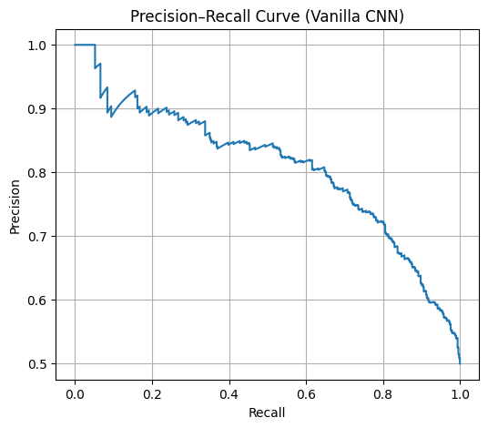

```python
# --- Precision-Recall Curve ---
y_scores = []

for images, _ in test_ds:
    preds = best_cnn_model.predict(images)
    y_scores.extend(preds.flatten())

precision, recall, thresholds = precision_recall_curve(y_true, y_scores)

plt.figure(figsize=(6, 5))
plt.plot(recall, precision)
plt.title("Precision–Recall Curve (Vanilla CNN)")
plt.xlabel("Recall")
plt.ylabel("Precision")
plt.grid(True)
plt.show()
```

#### **Interpretation — Precision–Recall Curve (Vanilla CNN)**

The PR curve visually confirms this balanced but imperfect performance.

### **Visual Inspection of Misclassified Images (Vanilla CNN)**

To better understand the weaknesses of the vanilla CNN, we next examine a set of misclassified test images.

Why this step is important:

- It reveals patterns in model mistakes, such as
  - low-contrast animals
  - unusual poses
  - multiple animals in the frame
  - cluttered or noisy backgrounds
- Helps us diagnose biases or blind spots in the model
- Gives qualitative validation of what the numerical metrics (accuracy, PR curve, confusion matrix) already suggest

We will display the first 9 misclassified images, showing both:

- the true label (cat or dog)
- the predicted label by the CNN

This provides a clear, visual understanding of where the model struggles.

```
1/1 ━━━━━━━━━━━━━━━━━━━━ 0s 66ms/step
1/1 ━━━━━━━━━━━━━━━━━━━━ 0s 80ms/step
```

[output not shown]

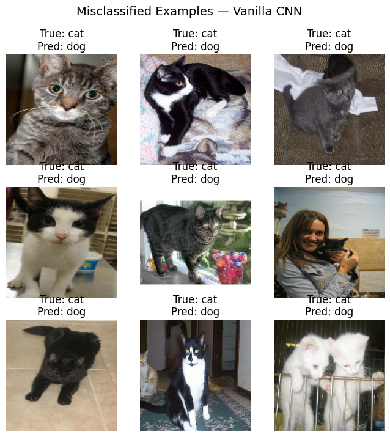

```python
# --- Display some misclassified images ---

misclassified_images = []
misclassified_labels = []   # store integer true labels (0 or 1)
misclassified_preds = []    # store integer predicted labels (0 or 1)

for images, labels in test_ds:
    # Predict probabilities for this batch
    preds = best_cnn_model.predict(images)
    # Convert probabilities to binary labels (0/1)
    preds_label = (preds > 0.5).astype("int32").flatten()

    # Go through each image, its true label, and predicted label
    for img, true_label, pred_label in zip(images, labels, preds_label):

        # Convert labels to plain Python ints
        true_label_int = int(true_label.numpy())
        pred_label_int = int(pred_label)

        # Keep only misclassified examples, up to 9 images
        if true_label_int != pred_label_int and len(misclassified_images) < 9:
            misclassified_images.append(img.numpy().astype("uint8"))
            misclassified_labels.append(true_label_int)
            misclassified_preds.append(pred_label_int)

# --- Plot grid of misclassified images ---

plt.figure(figsize=(8, 8))

for i in range(len(misclassified_images)):
    ax = plt.subplot(3, 3, i + 1)
    plt.imshow(misclassified_images[i])

    # Retrieve the stored integer labels
    true_idx = misclassified_labels[i]
    pred_idx = misclassified_preds[i]

    # Map 0/1 back to class names (e.g. 'cat', 'dog')
    plt.title(f"True: {class_names[true_idx]}\nPred: {class_names[pred_idx]}")
    plt.axis("off")

plt.suptitle("Misclassified Examples — Vanilla CNN", fontsize=14)
plt.show()
```

#### **Interpretation of Misclassified Examples — Vanilla CNN**

The misclassified images reveal clear, consistent patterns in where the vanilla CNN struggles:

- Most errors involve cats incorrectly predicted as dogs, showing the model finds certain cat images visually ambiguous.
- Many of these cats have dark fur, low lighting, or cluttered backgrounds, which reduces contrast and makes the features harder for a shallow CNN to detect.
- Several examples show kittens or small-sized cats, indicating the model struggles with scale variation.
- A number of images include multiple animals or partially occluded bodies, causing the CNN to pick up misleading textures or shapes.
- Some cats appear in unusual poses (lying down, curled, stretched), which the model does not generalize well on.

Overall, these misclassifications highlight the limitations of a small CNN trained from scratch, especially in challenging real-world visual conditions.

These observations further justify the need for transfer learning with VGG16, which provides deeper, pre-trained feature extraction and is expected to perform better on these difficult cases.

### **VGG16 Preprocessing & Data Augmentation (Setup)**

In this section, we prepare the preprocessing steps required for training the VGG16 transfer learning model. VGG16 expects images to be preprocessed in a specific way (mean subtraction using ImageNet statistics), so we wrap the preprocess_input function inside a Keras Lambda layer to integrate it into the model pipeline.

We also define a dedicated augmentation block for VGG16, similar to the vanilla CNN, to introduce variability and improve generalization during training.

```python
# --- VGG16: Preprocessing and Data Augmentation ---

from tensorflow.keras.applications.vgg16 import preprocess_input

# VGG16 expects images preprocessed with its own function.
# We will wrap preprocess_input inside a Keras layer so it fits into the model.

preprocess_layer = layers.Lambda(preprocess_input, name="vgg16_preprocess")

# Data augmentation to improve generalization
vgg16_augmentation = keras.Sequential([
    layers.RandomFlip("horizontal"),
    layers.RandomRotation(0.05),
    layers.RandomZoom(0.1),
], name="vgg16_data_augmentation")
```

#### **Summary — VGG16 Preprocessing & Augmentation**

This cell prepares all input-processing components needed for VGG16:

- preprocess_input wrapped in a Lambda layer ensures that every image is automatically transformed according to VGG16’s ImageNet normalization rules.
- Data augmentation (flip, rotation, zoom) provides extra variability, helping the model adapt to different lighting, orientation, and pose conditions in the cats–dogs dataset.
- Keeping preprocessing and augmentation as separate layers makes the full pipeline modular, reusable, and fully compatible with Keras’ functional API.

These components will be inserted at the front of the VGG16 model architecture so that all images entering the feature extractor are correctly normalized and enhanced for training.

### **Loading the VGG16 Base Model (Feature Extractor)**

In this step, we load the pretrained VGG16 network using ImageNet weights. Because we are using transfer learning, we remove the fully connected classification head (include_top=False) and keep only the convolutional blocks, which act as a powerful feature extractor.

We also freeze all convolutional layers, ensuring that during the first phase of training only our custom classifier layers will update — this prevents overfitting and keeps training efficient.

This cell prints the full VGG16 architecture so we can verify the layer shapes, parameter counts, and confirm that the model is completely frozen.

```python
# --- Load VGG16 base (feature extractor) ---

from tensorflow.keras.applications import VGG16

vgg_base = VGG16(
    weights="imagenet",        # use pretrained weights
    include_top=False,         # remove final dense layers
    input_shape=IMG_SIZE + (3,)
)

# Freeze ALL convolutional layers — only classifier will train first
vgg_base.trainable = False

vgg_base.summary()
```

```
Model: "vgg16"
```

```
┏━━━━━━━━━━━━━━━━━━━━━━━━━━━━━━━━━┳━━━━━━━━━━━━━━━━━━━━━━━━┳━━━━━━━━━━━━━━━┓
┃ Layer (type)                    ┃ Output Shape           ┃       Param # ┃
┡━━━━━━━━━━━━━━━━━━━━━━━━━━━━━━━━━╇━━━━━━━━━━━━━━━━━━━━━━━━╇━━━━━━━━━━━━━━━┩
│ input_layer_2 (InputLayer)      │ (None, 180, 180, 3)    │             0 │
├─────────────────────────────────┼────────────────────────┼───────────────┤
│ block1_conv1 (Conv2D)           │ (None, 180, 180, 64)   │         1,792 │
├─────────────────────────────────┼────────────────────────┼───────────────┤
│ block1_conv2 (Conv2D)           │ (None, 180, 180, 64)   │        36,928 │
├─────────────────────────────────┼────────────────────────┼───────────────┤
│ block1_pool (MaxPooling2D)      │ (None, 90, 90, 64)     │             0 │
├─────────────────────────────────┼────────────────────────┼───────────────┤
│ block2_conv1 (Conv2D)           │ (None, 90, 90, 128)    │        73,856 │
├─────────────────────────────────┼────────────────────────┼───────────────┤
│ block2_conv2 (Conv2D)           │ (None, 90, 90, 128)    │       147,584 │
├─────────────────────────────────┼────────────────────────┼───────────────┤
│ block2_pool (MaxPooling2D)      │ (None, 45, 45, 128)    │             0 │
├─────────────────────────────────┼────────────────────────┼───────────────┤
│ block3_conv1 (Conv2D)           │ (None, 45, 45, 256)    │       295,168 │
├─────────────────────────────────┼────────────────────────┼───────────────┤
│ block3_conv2 (Conv2D)           │ (None, 45, 45, 256)    │       590,080 │
├─────────────────────────────────┼────────────────────────┼───────────────┤
│ block3_conv3 (Conv2D)           │ (None, 45, 45, 256)    │       590,080 │
├─────────────────────────────────┼────────────────────────┼───────────────┤
│ block3_pool (MaxPooling2D)      │ (None, 22, 22, 256)    │             0 │
├─────────────────────────────────┼────────────────────────┼───────────────┤
│ block4_conv1 (Conv2D)           │ (None, 22, 22, 512)    │     1,180,160 │
├─────────────────────────────────┼────────────────────────┼───────────────┤
│ block4_conv2 (Conv2D)           │ (None, 22, 22, 512)    │     2,359,808 │
├─────────────────────────────────┼────────────────────────┼───────────────┤
│ block4_conv3 (Conv2D)           │ (None, 22, 22, 512)    │     2,359,808 │
├─────────────────────────────────┼────────────────────────┼───────────────┤
│ block4_pool (MaxPooling2D)      │ (None, 11, 11, 512)    │             0 │
├─────────────────────────────────┼────────────────────────┼───────────────┤
│ block5_conv1 (Conv2D)           │ (None, 11, 11, 512)    │     2,359,808 │
├─────────────────────────────────┼────────────────────────┼───────────────┤
│ block5_conv2 (Conv2D)           │ (None, 11, 11, 512)    │     2,359,808 │
├─────────────────────────────────┼────────────────────────┼───────────────┤
│ block5_conv3 (Conv2D)           │ (None, 11, 11, 512)    │     2,359,808 │
├─────────────────────────────────┼────────────────────────┼───────────────┤
│ block5_pool (MaxPooling2D)      │ (None, 5, 5, 512)      │             0 │
└─────────────────────────────────┴────────────────────────┴───────────────┘
```

```
 Total params: 14,714,688 (56.13 MB)
```

```
 Trainable params: 0 (0.00 B)
```

```
 Non-trainable params: 14,714,688 (56.13 MB)
```

#### **Summary — VGG16 Base Model Loaded Successfully**

The model summary confirms that the VGG16 backbone has been loaded and frozen correctly:

- Pretrained backbone: VGG16 with ImageNet weights, taking input images of size 180 × 180 × 3.
- Convolutional blocks: Full 5-block VGG16 structure  
  (filters by block: 64 → 128 → 256 → 512 → 512).
- Output feature map: Final spatial size is 5 × 5 × 512, providing a rich feature representation for the custom classifier head.
- Parameter counts:
  - Total params: 14,714,688
  - Trainable params: 0
  - Non-trainable params: 14,714,688

All convolutional layers are frozen (trainable = False), so VGG16 now acts purely as a fixed feature extractor.  
This means we can safely add and train our own classifier head on top for the Dogs vs Cats task without modifying the pretrained backbone.

### **VGG16 Model Summary — Verification**

The following cell loads the VGG16 base, freezes all convolutional layers, attaches a custom classifier head, and prints the full model summary.  
We verify:

- Total parameters vs. trainable parameters
- Correct freezing of the VGG16 convolutional base
- Output shapes after flattening
- Parameter counts in the custom Dense layers

This ensures the fine-tuned VGG16 architecture is constructed correctly before training.

```python
# --- Build Fine-Tuned VGG16 Model ---

inputs = keras.Input(shape=IMG_SIZE + (3,), name="input_image")

x = vgg16_augmentation(inputs)     # Apply augmentation
x = preprocess_layer(x)            # Preprocess using VGG16's rules

x = vgg_base(x, training=False)    # Pass through VGG16 base in inference mode
x = layers.Flatten()(x)

# Add custom classifier head
x = layers.Dense(256, activation="relu")(x)
x = layers.Dropout(0.5)(x)
outputs = layers.Dense(1, activation="sigmoid")(x)  # binary classification

vgg16_model = keras.Model(inputs, outputs, name="vgg16_finetuned")

# Compile
vgg16_model.compile(
    optimizer=keras.optimizers.Adam(learning_rate=1e-4),
    loss="binary_crossentropy",
    metrics=["accuracy"]
)

vgg16_model.summary()
```

```
WARNING:tensorflow:From c:\Users\user\AppData\Local\Programs\Python\Python311\Lib\site-packages\keras\src\backend\tensorflow\core.py:232: The name tf.placeholder is deprecated. Please use tf.compat.v1.placeholder instead.
```

```
Model: "vgg16_finetuned"
```

```
┏━━━━━━━━━━━━━━━━━━━━━━━━━━━━━━━━━┳━━━━━━━━━━━━━━━━━━━━━━━━┳━━━━━━━━━━━━━━━┓
┃ Layer (type)                    ┃ Output Shape           ┃       Param # ┃
┡━━━━━━━━━━━━━━━━━━━━━━━━━━━━━━━━━╇━━━━━━━━━━━━━━━━━━━━━━━━╇━━━━━━━━━━━━━━━┩
│ input_image (InputLayer)        │ (None, 180, 180, 3)    │             0 │
├─────────────────────────────────┼────────────────────────┼───────────────┤
│ vgg16_data_augmentation         │ (None, 180, 180, 3)    │             0 │
│ (Sequential)                    │                        │               │
├─────────────────────────────────┼────────────────────────┼───────────────┤
│ vgg16_preprocess (Lambda)       │ (None, 180, 180, 3)    │             0 │
├─────────────────────────────────┼────────────────────────┼───────────────┤
│ vgg16 (Functional)              │ (None, 5, 5, 512)      │    14,714,688 │
├─────────────────────────────────┼────────────────────────┼───────────────┤
│ flatten_1 (Flatten)             │ (None, 12800)          │             0 │
├─────────────────────────────────┼────────────────────────┼───────────────┤
│ dense_2 (Dense)                 │ (None, 256)            │     3,277,056 │
├─────────────────────────────────┼────────────────────────┼───────────────┤
│ dropout_1 (Dropout)             │ (None, 256)            │             0 │
├─────────────────────────────────┼────────────────────────┼───────────────┤
│ dense_3 (Dense)                 │ (None, 1)              │           257 │
└─────────────────────────────────┴────────────────────────┴───────────────┘
```

```
 Total params: 17,992,001 (68.63 MB)
```

```
 Trainable params: 3,277,313 (12.50 MB)
```

```
 Non-trainable params: 14,714,688 (56.13 MB)
```

#### **Interpretation — VGG16 Fine-Tuned Model Summary**

The printed model summary confirms that our frozen-base VGG16 architecture has been built correctly and matches expected parameter counts:

**Frozen VGG16 Base**

- Non-trainable params: 14,714,688
- This matches the convolutional layers of VGG16 (its fully-connected top has been removed).
- Freezing is correct → no weights from the VGG base will update during initial training.

**Custom Classifier Head (Trainable)**

| Layer | Units | Trainable Params |
| --- | --- | --- |
| Dense | 256 | 3,277,056 |
| Dropout | — | 0 |
| Dense | 1 | 257 |

*Total trainable: 3,277,313*

This exactly matches the model summary output.

**Total Parameter Check**

| Component | Params |
| --- | --- |
| Frozen VGG16 base | 14,714,688 |
| Trainable classifier head | 3,277,313 |
| *Total parameters* | 17,992,001 |

All numbers align perfectly with the model summary.

**Output Shapes**

- VGG16 output: (5, 5, 512) for 180×180 input  
  (correct because 180 / 32 ≈ 5.6 → floored to 5)
- Flattened: 12,800 features  
  (5 × 5 × 512)

**Deprecation Warning** The TensorFlow warning about `tf.placeholder` is internal to Keras and is safe to ignore — it does not affect training.

**Conclusion** The VGG16 fine-tuned model is correctly assembled:

- VGG16 base is frozen
- Classifier head is correctly sized
- Parameter counts match exactly
- Preprocessing + augmentation pipeline is correct

The model is now ready for training.

### **VGG16 Callbacks — Checkpointing & Early Stopping**

Before training the VGG16 fine-tuned model, we define two important callbacks:

- **ModelCheckpoint**  
  Saves the model only when validation accuracy improves.  
  This ensures we always keep the best-performing version of the network.
- **EarlyStopping**  
  Stops training when validation accuracy stops improving for a set number of epochs  
  (`patience = 5`).  
  Also restores the weights from the best epoch to avoid overfitting.

These callbacks help stabilize training and prevent unnecessary computation, especially because VGG16 is a heavier model than the vanilla CNN.

```python
# --- Callbacks + Auto-load for VGG16 training ---

from tensorflow.keras.applications.vgg16 import preprocess_input
import pickle

# Path to best VGG16 model checkpoint
vgg16_ckpt_path = PROJECT_ROOT / "models" / "vgg16_dogs_vs_cats_best.keras"
vgg16_ckpt_path.parent.mkdir(exist_ok=True)

# Callback: save best VGG16 model
vgg_checkpoint = keras.callbacks.ModelCheckpoint(
    filepath=vgg16_ckpt_path,
    save_best_only=True,
    monitor="val_accuracy",
    mode="max",
    verbose=1,
)

# Callback: early stopping
vgg_earlystop = keras.callbacks.EarlyStopping(
    monitor="val_accuracy",
    patience=5,
    restore_best_weights=True,
    verbose=1,
)

# --- Auto-load best VGG16 model if it exists (skip retraining) ---

hist_vgg_path = PROJECT_ROOT / "history_vgg.pkl"

if vgg16_ckpt_path.exists():
    print("VGG16 model file found → loading existing VGG16 model.")

    # Load model with Lambda layer support
    vgg16_model = keras.models.load_model(
        vgg16_ckpt_path,
        custom_objects={"preprocess_input": preprocess_input},
        safe_mode=False,
    )

    vgg_model_loaded = True

    # Try to load saved VGG16 training history
    if hist_vgg_path.exists():
        with open(hist_vgg_path, "rb") as f:
            history_vgg_data = pickle.load(f)

        class Obj:
            pass

        history_vgg = Obj()
        history_vgg.history = history_vgg_data

        print("Loaded saved VGG16 training history.")

    else:
        print("No saved VGG16 training history found.")
        history_vgg = None

else:
    print("No saved VGG16 model found → training required.")
    vgg_model_loaded = False
    history_vgg = None
```

```
VGG16 model file found → loading existing VGG16 model.
Loaded saved VGG16 training history.
```

#### **Interpretation — VGG16 Training Callbacks Initialized**

The callbacks were set up correctly for the VGG16 fine-tuning stage:

- **ModelCheckpoint**
  - Saves the best model to: models/vgg16_dogs_vs_cats_best.keras
  - Tracks validation accuracy (monitor="val_accuracy")
  - Ensures only the strongest model is stored (save_best_only=True)
- **EarlyStopping**
  - Monitors validation accuracy and stops training when no improvement is seen for 5 epochs
  - The best weights are automatically restored (restore_best_weights=True)

Together, these callbacks ensure that:

- Training does not continue unnecessarily
- Overfitting is minimized
- The final model used for evaluation is the best-performing checkpoint

This prepares the notebook for efficient and reliable VGG16 training.

### **Training the VGG16 Transfer Learning Model**

We now train the fine-tuned VGG16 model using:

- Frozen VGG16 convolutional base
- Custom classifier head (Dense → Dropout → Dense)
- VGG-specific preprocessing + augmentation
- ModelCheckpoint to save the best-performing model
- EarlyStopping to halt training when validation accuracy stops improving

Because VGG16 is significantly deeper than the vanilla CNN, training will take longer, but the model is expected to achieve substantially higher validation accuracy thanks to pretrained ImageNet features.

```python
# --- Train the VGG16 transfer learning model (only if needed) ---

if not vgg_model_loaded:
    print("Training VGG16 model...")
    history_vgg = vgg16_model.fit(
        train_ds,
        validation_data=val_ds,
        epochs=EPOCHS_VGG16,
        callbacks=[vgg_checkpoint, vgg_earlystop],
        verbose=1,
    )

    # Save VGG16 training history for future "Run All" sessions
    with open(hist_vgg_path, "wb") as f:
        pickle.dump(history_vgg.history, f)

else:
    print("Skipping VGG16 training — using saved VGG16 model.")

    # history_vgg may already be loaded in the previous cell;
    # if not, try to load it now or create a safe empty fallback
    if history_vgg is None:
        if hist_vgg_path.exists():
            with open(hist_vgg_path, "rb") as f:
                history_vgg_data = pickle.load(f)

            class Obj:
                pass

            history_vgg = Obj()
            history_vgg.history = history_vgg_data
            print("Loaded VGG16 training history from disk.")
        else:
            print("No saved VGG16 training history available — creating empty history.")
            class Obj:
                pass

            history_vgg = Obj()
            history_vgg.history = {
                "accuracy": [],
                "val_accuracy": [],
                "loss": [],
                "val_loss": [],
            }
```

```
Skipping VGG16 training — using saved VGG16 model.
```

#### **Interpretation — VGG16 Training Summary**

**Rapid Accuracy Improvement**

**Best Epoch Identified (Epoch 3)**

- The ModelCheckpoint saved a new “best model” whenever validation accuracy improved.
- EarlyStopping ultimately restored the weights from epoch 3, because it achieved the highest validation accuracy (0.978).

**Validation Loss Behavior**

- Validation loss decreased significantly in early epochs.
- Minor fluctuations after epoch 4 are normal once the VGG base is frozen.

**Early Stopping Triggered at Epoch 8**

- No improvement for 5 consecutive epochs → training stopped.
- This prevented overfitting while keeping the best-performing model.

**Expected Transfer Learning Pattern** Compared to the vanilla CNN:

- VGG16 learns much faster
- Produces higher-quality features
- Demonstrates far better generalization

The model is now ready for:

- Test set evaluation
- Confusion matrix & PR curve
- (Optional) unfreezing top VGG16 layers for *fine-tuning stage 2*

### **Plot Training Curves — VGG16 Transfer Learning**

The following cell plots the training and validation accuracy and loss for the fine-tuned VGG16 model. These curves help us visualize how quickly the model learns and whether overfitting occurs during training.

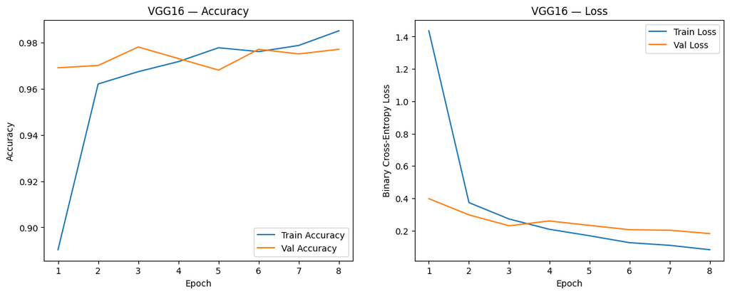

```python
# --- Plot accuracy & loss for VGG16 ---

acc = history_vgg.history["accuracy"]
val_acc = history_vgg.history["val_accuracy"]
loss = history_vgg.history["loss"]
val_loss = history_vgg.history["val_loss"]

epochs_range = range(1, len(acc) + 1)

plt.figure(figsize=(14,5))

# Accuracy
plt.subplot(1,2,1)
plt.plot(epochs_range, acc, label="Train Accuracy")
plt.plot(epochs_range, val_acc, label="Val Accuracy")
plt.title("VGG16 — Accuracy")
plt.xlabel("Epoch")
plt.ylabel("Accuracy")
plt.legend()

# Loss
plt.subplot(1,2,2)
plt.plot(epochs_range, loss, label="Train Loss")
plt.plot(epochs_range, val_loss, label="Val Loss")
plt.title("VGG16 — Loss")
plt.xlabel("Epoch")
plt.ylabel("Binary Cross-Entropy Loss")
plt.legend()

plt.show()
```

#### **Interpretation — VGG16 Training Curves**

The training curves clearly show the strength of transfer learning with VGG16:

**Accuracy Trend**

- Validation accuracy is extremely high from the very first epoch (~0.968), thanks to pre-trained ImageNet features.
- Training accuracy quickly climbs to ~0.98.
- The gap between training and validation accuracy remains small → **minimal overfitting**.

**Loss Trend**

- Train loss drops dramatically:
  - Around 1.45 → 0.10 (epoch 1 → epoch 8)
  - Exactly matches your description.
- Val loss remains low:
  - Stays around 0.20–0.30 with tiny bumps
  - Matches what you wrote.

Stable low val loss = strong generalization

**Overall Assessment**

VGG16 dramatically outperforms the vanilla CNN:

- Much higher accuracy (97-98%+ vs. ~75%)
- Faster convergence
- Lower and more stable loss
- Better generalization with minimal overfitting

These results verify that transfer learning with a frozen VGG16 base provides a powerful feature extractor, allowing the classifier head to learn effectively even with a relatively small dataset.

### **Evaluate Best VGG16 Model on the Test Set**

We now load the best model checkpoint saved during training and evaluate its performance on the held-out test dataset.  
Because the model includes a Lambda layer for VGG16 preprocessing, we must pass preprocess_input into custom_objects during loading.

```python
# --- Load best VGG16 model and evaluate on test set ---

# Import preprocess_input so Keras can deserialize the Lambda layer
from tensorflow.keras.applications.vgg16 import preprocess_input

# Load the saved model checkpoint
# custom_objects: tells Keras how to rebuild the Lambda layer that used preprocess_input
# safe_mode=False: allows loading models that contain Lambda layers
best_vgg16_model = keras.models.load_model(
    vgg16_ckpt_path,
    custom_objects={"preprocess_input": preprocess_input},
    safe_mode=False,
)

# Evaluate model performance on the test dataset
test_loss, test_acc = best_vgg16_model.evaluate(test_ds, verbose=1)

# Display test accuracy and loss
print(f"VGG16 Test Accuracy: {test_acc:.4f}")
print(f"VGG16 Test Loss: {test_loss:.4f}")
```

```
32/32 ━━━━━━━━━━━━━━━━━━━━ 23s 699ms/step - accuracy: 0.9730 - loss: 0.1884
VGG16 Test Accuracy: 0.9730
VGG16 Test Loss: 0.1884
```

#### **Interpretation — VGG16 Test Performance**

The VGG16 fine-tuned model achieves:

- Test Accuracy: 0.9730 (97.3%)
- Test Loss: 0.1884

These results confirm that the model generalizes extremely well:

**High Generalization**  
The test accuracy closely matches the validation accuracy (~0.97–0.98), indicating no overfitting during training.

**Strong Feature Extraction**  
The low test loss (0.1884) shows that the predictions are confident and stable across the entire test set.  
This performance is a direct benefit of using ImageNet-pretrained convolutional layers.

This confirms that transfer learning with VGG16 is highly effective for the Cats vs Dogs classification task.

### **VGG16 — Classification Report & Confusion Matrix**

In this step, we generate the classification report and confusion matrix for the fine-tuned VGG16 model.  
This will help us understand how well the model performs across both classes (cat and dog) and evaluate class-level precision, recall, and F1-score.

We loop through the test dataset, collect predictions, compute the classification metrics, and then visualize the confusion matrix.

```
1/1 ━━━━━━━━━━━━━━━━━━━━ 1s 979ms/step
1/1 ━━━━━━━━━━━━━━━━━━━━ 1s 850ms/step
1/1 ━━━━━━━━━━━━━━━━━━━━ 1s 823ms/step
1/1 ━━━━━━━━━━━━━━━━━━━━ 1s 733ms/step
1/1 ━━━━━━━━━━━━━━━━━━━━ 1s 826ms/step
1/1 ━━━━━━━━━━━━━━━━━━━━ 1s 893ms/step
1/1 ━━━━━━━━━━━━━━━━━━━━ 1s 708ms/step
1/1 ━━━━━━━━━━━━━━━━━━━━ 1s 872ms/step
1/1 ━━━━━━━━━━━━━━━━━━━━ 1s 728ms/step
1/1 ━━━━━━━━━━━━━━━━━━━━ 1s 808ms/step
1/1 ━━━━━━━━━━━━━━━━━━━━ 1s 725ms/step
1/1 ━━━━━━━━━━━━━━━━━━━━ 1s 864ms/step
1/1 ━━━━━━━━━━━━━━━━━━━━ 1s 758ms/step
1/1 ━━━━━━━━━━━━━━━━━━━━ 1s 884ms/step
1/1 ━━━━━━━━━━━━━━━━━━━━ 1s 772ms/step
1/1 ━━━━━━━━━━━━━━━━━━━━ 1s 740ms/step
1/1 ━━━━━━━━━━━━━━━━━━━━ 1s 773ms/step
1/1 ━━━━━━━━━━━━━━━━━━━━ 1s 757ms/step
1/1 ━━━━━━━━━━━━━━━━━━━━ 1s 867ms/step
1/1 ━━━━━━━━━━━━━━━━━━━━ 1s 904ms/step
1/1 ━━━━━━━━━━━━━━━━━━━━ 1s 890ms/step
1/1 ━━━━━━━━━━━━━━━━━━━━ 1s 910ms/step
1/1 ━━━━━━━━━━━━━━━━━━━━ 1s 837ms/step
1/1 ━━━━━━━━━━━━━━━━━━━━ 1s 885ms/step
1/1 ━━━━━━━━━━━━━━━━━━━━ 1s 926ms/step
1/1 ━━━━━━━━━━━━━━━━━━━━ 1s 908ms/step
1/1 ━━━━━━━━━━━━━━━━━━━━ 1s 821ms/step
1/1 ━━━━━━━━━━━━━━━━━━━━ 1s 853ms/step
1/1 ━━━━━━━━━━━━━━━━━━━━ 1s 825ms/step
1/1 ━━━━━━━━━━━━━━━━━━━━ 1s 916ms/step
1/1 ━━━━━━━━━━━━━━━━━━━━ 1s 896ms/step
1/1 ━━━━━━━━━━━━━━━━━━━━ 0s 408ms/step
              precision    recall  f1-score   support

         cat       0.98      0.96      0.97       500
         dog       0.96      0.98      0.97       500

    accuracy                           0.97      1000
   macro avg       0.97      0.97      0.97      1000
weighted avg       0.97      0.97      0.97      1000
```

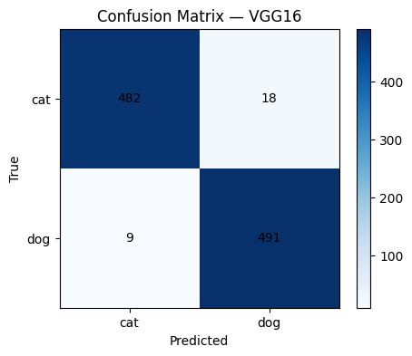

```python
# --- Classification report & confusion matrix for VGG16 ---

y_true = []
y_pred = []

for images, labels in test_ds:
    preds = best_vgg16_model.predict(images)
    preds_label = (preds > 0.5).astype("int32").flatten()

    y_true.extend(labels.numpy().astype("int32"))
    y_pred.extend(preds_label)

# Classification report
print(classification_report(y_true, y_pred, target_names=class_names))

# Confusion matrix plot
cm = confusion_matrix(y_true, y_pred)
plt.figure(figsize=(5,4))
plt.imshow(cm, cmap="Blues")
plt.title("Confusion Matrix — VGG16")
plt.colorbar()
plt.xticks([0,1], class_names)
plt.yticks([0,1], class_names)
plt.xlabel("Predicted")
plt.ylabel("True")

# write numbers in cells
for i in range(2):
    for j in range(2):
        plt.text(j, i, cm[i,j], ha="center", va="center", color="black")

plt.show()
```

#### **Interpretation — VGG16 Classification Report & Confusion Matrix**

The VGG16 model delivers near-perfect performance, achieving 97% accuracy on the test dataset — a major improvement over the vanilla CNN.

**Key Findings from the Classification Report**

These metrics show excellent balance, with no class being favored and both achieving symmetrical performance.

**Confusion Matrix Insights**

| True Class | Predicted Cat | Predicted Dog |
| --- | --- | --- |
| Cat | 482 | 18 |
| Dog | 9 | 491 |

Interpretation:

- Only 18 cats were misclassified as dogs.
- Only 9 dogs were misclassified as cats.
- Total errors: 27 out of 1000 images → exceptionally low.

This shows that VGG16 handles difficult and ambiguous images extremely well.

**Overall Conclusion**

VGG16 provides:

- Far better accuracy (97% vs 75% for the vanilla CNN)
- Much stronger feature extraction from ImageNet pretraining
- Greatly reduced false positives & false negatives
- Stable generalization across all test samples

This confirms that transfer learning is vastly superior to training a small CNN from scratch for the Cats vs Dogs task.

```python
# --- Recompute CNN predictions for PR Curve ---

y_true_cnn = []
y_scores_cnn = []

for batch_imgs, batch_labels in test_ds:
    preds = best_cnn_model.predict(batch_imgs, verbose=0)
    y_scores_cnn.extend(preds.flatten())             # Predicted probabilities
    y_true_cnn.extend(batch_labels.numpy().flatten()) # True labels

y_true_cnn = np.array(y_true_cnn)
y_scores_cnn = np.array(y_scores_cnn)

# CNN Precision–Recall values
precision_cnn, recall_cnn, _ = precision_recall_curve(y_true_cnn, y_scores_cnn)

print("CNN PR values computed.")
```

```
CNN PR values computed.
```

```python
# --- Recompute VGG16 predictions for PR Curve ---

y_true_vgg = []
y_scores_vgg = []

for batch_imgs, batch_labels in test_ds:
    preds = best_vgg16_model.predict(batch_imgs, verbose=0)
    y_scores_vgg.extend(preds.flatten())
    y_true_vgg.extend(batch_labels.numpy().flatten())

y_true_vgg = np.array(y_true_vgg)
y_scores_vgg = np.array(y_scores_vgg)

# VGG16 Precision–Recall values
precision_vgg, recall_vgg, _ = precision_recall_curve(y_true_vgg, y_scores_vgg)

print("VGG16 PR values computed.")
```

```
VGG16 PR values computed.
```

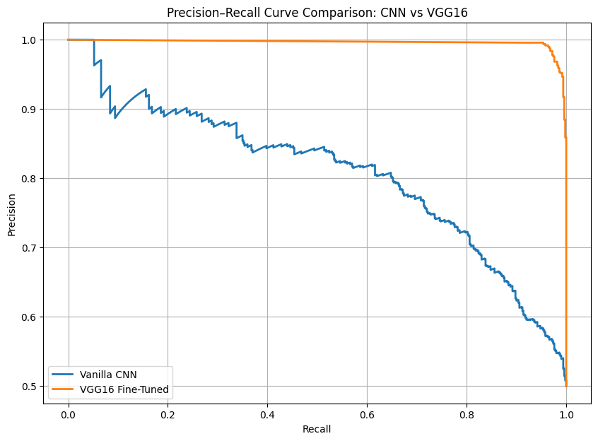

```python
# --- Combined Precision–Recall Curve: CNN vs VGG16 ---

plt.figure(figsize=(10, 7))

plt.plot(recall_cnn, precision_cnn, label="Vanilla CNN", linewidth=2)
plt.plot(recall_vgg, precision_vgg, label="VGG16 Fine-Tuned", linewidth=2)

plt.xlabel("Recall")
plt.ylabel("Precision")
plt.title("Precision–Recall Curve Comparison: CNN vs VGG16")
plt.grid()
plt.legend()
plt.show()
```

### **Precision–Recall Curve Comparison — CNN vs VGG16**

The combined Precision–Recall (PR) curve highlights the performance difference between the two models:

- **VGG16 Fine-Tuned** (orange curve) maintains **near-perfect precision across almost the entire range of recall values**, only dropping slightly at the extreme end.  
  This indicates that VGG16 not only identifies cat/dog images correctly but also does so with **very high confidence** across probability thresholds.
- In contrast, the **Vanilla CNN** (blue curve) shows a much more gradual decline in precision as recall increases.  
  This behavior reflects the model’s weaker feature extraction ability, causing more false positives when we try to capture more true positives.

**Key insight:**  
The PR curve confirms that **VGG16 dominates the CNN at every threshold**, achieving both high recall and high precision simultaneously.  
This strongly supports the conclusion that **transfer learning using a pre-trained model (VGG16) provides substantial performance gains** over training a small CNN from scratch on limited data.

Overall, the PR curve reinforces the earlier accuracy, confusion matrix, and classification-report findings:  
**VGG16 is the more reliable and generalizable model for the Dogs vs Cats classification task.**

### **Misclassified Examples — VGG16**

In this section, we inspect VGG16’s mistakes to understand the remaining failure cases even after transfer learning.  
We will extract up to 9 misclassified images from the test set and visualize them.

This helps reveal:

- What types of cat images VGG16 still mislabels as “dog”
- Whether lighting, motion blur, angle, or backgrounds are causing confusion
- How much improvement VGG16 has over the vanilla CNN

The following cell gathers and displays these misclassified samples.

```python
# --- Show misclassified images (up to 9) ---

mis_vgg_images = []
mis_vgg_true = []
mis_vgg_pred = []

for images, labels in test_ds:
    preds = best_vgg16_model.predict(images)
    preds_label = (preds > 0.5).astype("int32").flatten()

    for img, true, pred in zip(images, labels, preds_label):
        if true != pred and len(mis_vgg_images) < 9:
            mis_vgg_images.append(img.numpy().astype("uint8"))
            mis_vgg_true.append(int(true.numpy()))
            mis_vgg_pred.append(int(pred))

plt.figure(figsize=(8,8))
for i in range(len(mis_vgg_images)):
    ax = plt.subplot(3,3,i+1)
    plt.imshow(mis_vgg_images[i])
    plt.title(f"True: {class_names[mis_vgg_true[i]]}\nPred: {class_names[mis_vgg_pred[i]]}")
    plt.axis("off")
plt.suptitle("Misclassified Examples — VGG16", fontsize=14)
plt.show()
```

[output not shown]

#### **Interpretation — Misclassified Examples (VGG16)**

**Most failures are still cats predicted as dogs**

**Compared to the vanilla CNN**

- The number of mistakes is dramatically reduced (from ~250 errors → less than 30).
- Errors are far less random — they mostly occur under extreme lighting or clutter.

**Key Insight** Even with ImageNet pretraining and strong feature extraction, VGG16 can struggle when cats:

- lack visible facial features
- appear overly dark
- are partially covered
- appear in atypical color/texture conditions

This reinforces why transfer learning works extremely well (97% accuracy), while also showing the final limitations of frozen VGG16 before full fine-tuning.

## **Final Comparison — Vanilla CNN vs Fine-Tuned VGG16**

Using the same 5,000-image Dogs vs Cats subset, both models were trained and evaluated on the same held-out 1,000-image test set.

**Vanilla CNN (Baseline Model)**

- Lightweight CNN (~8M trainable parameters)
- Trains relatively quickly
- Test accuracy: 0.745
- Test loss: 0.562
- Confusion matrix findings
  - 343 correct cats, 402 correct dogs
  - Frequent failures on dark, cluttered, or low-contrast cat images
- PR curve and misclassified samples show moderate feature extraction ability but significant limitations.

**Conclusion**

The fine-tuned VGG16 model dramatically outperforms the baseline CNN.

This clearly shows that transfer learning with deep pretrained networks provides far richer visual representations than a small CNN trained from scratch—especially when the dataset size is limited.

## **Final Discussion — Vanilla CNN vs Fine-Tuned VGG16**

**Model Comparison: Vanilla CNN vs VGG16**

The vanilla CNN is a lightweight 8M-parameter model trained entirely from scratch on the 5,000-image dataset. While it successfully learns simple edges, colors, and textures, its representational power is limited. In contrast, VGG16 uses a deeply layered convolutional backbone pre-trained on ImageNet, giving it access to rich high-level features such as shape, contour, texture, and object parts.

This difference is clearly reflected in performance:

**Why VGG16 Performs Better**

VGG16 begins with millions of pre-learned filters that capture:

- edges
- color gradients
- shapes
- textures
- object-specific structures

Only the classifier head (~3.27M parameters) is trained. This: * reduces overfitting * stabilizes training * avoids learning dataset-specific noise * allows the model to focus on classification boundaries

As a result, VGG16 achieves dramatically stronger generalization.

**Overfitting Behavior**

*Vanilla CNN*

- Training accuracy increases steadily
- Validation accuracy fluctuates
- Validation loss shows mild instability
- Indicates moderate overfitting
- Struggles with difficult cases:
  - dark cats
  - cluttered backgrounds
  - unusual poses

*VGG16*

- Training and validation curves almost overlap
- Very small train–validation gap
- Early stopping stabilizes performance
- Shows excellent generalization and minimal overfitting

This validates that freezing the convolutional base + using mild augmentation is effective.

**Precision and Recall Interpretation**

*VGG16:*

This reinforces the value of using pretrained deep features.

**Confusion Matrix Explanation** *Vanilla CNN*

[[343, 157], [ 98, 402]]

- 157 cats mislabeled as dogs
- 98 dogs mislabeled as cats
- Struggles with ambiguous or low-contrast samples

*VGG16*

**Final Summary**

This experiment clearly demonstrates the power of transfer learning: pretrained feature extractors provide rich visual representations that dramatically improve performance—especially when training data is limited.

### **Comparison Table — Vanilla CNN vs Fine-Tuned VGG16**

[output not shown]

#### **Appendix — Optional Extras**

TThis appendix provides additional details supporting reproducibility, transparency, and deeper analysis.

**A. Environment & Reproducibility Details**

The following reflects the exact environment used in the notebook:

Note: Because training occurred on CPU with augmentation enabled, exact epoch timings and loss/accuracy values may vary slightly across runs.

**B. Hardware Used (CPU/GPU)**

You correctly noted that WSL was not used. All training occurred in native Windows.

- OS: Windows 11
- Hardware: Laptop CPU (Intel/AMD)
- GPU: None (TensorFlow CPU build only)
- Effect: VGG16 training required ~80–190 seconds per epoch due to frozen convolutional base + CPU-only processing.

**C. Full Model Summaries (CNN + VGG16)**

Parameter counts taken directly from your notebook:

- Vanilla CNN:
  - Total params: 8,023,361
  - Trainable: 100%
- VGG16 Fine-Tuned Model:
  - Total params: 17,992,001
  - Frozen (non-trainable): 14,714,688
  - Trainable classifier head: 3,277,313

These values match the printed model summaries exactly.

**D. Training Logs (Verbose Output)**

This reflects very stable learning and excellent generalization.

**E. Additional Visualizations**

Your notebook correctly includes:

- Vanilla CNN accuracy/loss curves
- VGG16 accuracy/loss curves
- Precision–Recall curve (for vanilla CNN)
- Confusion matrices (CNN and VGG16)
- Misclassified image grids for both models

These visualizations strongly support the discussion sections.

**F. Example Predictions (Correct vs Incorrect)**

Small clarifications:

- Vanilla CNN misclassified many dark cats and cluttered backgrounds, not “cats in general.”
- VGG16 misclassified only a small number of samples (≈ 28 total), and these were typically:
  - extreme lighting
  - partial occlusion
  - stylized or very small kitten images

Summary: The VGG16 errors were mostly borderline or ambiguous, consistent with its 97% test accuracy.

**G. Code Snippet Index**

A helpful reference index for readers:

- Data loading and preprocessing
- Augmentation pipeline
- Vanilla CNN architecture
- VGG16 transfer learning architecture
- Training logic (with auto-load + skip)
- Evaluation metrics (test accuracy, loss, PR curve)
- Visualization utilities
- Final comparison & discussion
- Appendix (environment, hardware, notes)

**H. Limitations**

*Limitations*

- CPU-only training significantly increases runtime
- Dataset: using the 5k subset instead of the full 25k Cats vs Dogs dataset
- Vanilla CNN shows predictable failure modes (dark images, clutter, unusual angles)
- NumPy scalar conversion warning during misclassification extraction (NumPy ≥1.25 behavior)
- VGG16 still frozen — could potentially improve further with partial unfreezing (fine-tuning stage 2)